# Environmental factor that affects the abundance of bee (Eulaema nigrita) in the Mata Atlântica region (Brazil)

Márton Horváth

2023-11-24

## Introduction

In the following report, enviromental factors affecting the abundance of the bee species *Eulaema nigrita* are analyzed. The sampling of the bees was carried out in the Brazilian Atlantic forest region using three different methods: net, net traps and traps. *E. nigrita*, commonly known as the black orchid bee, it has an important ecological role as a pollinator in the tropical regions of the Americas, including Central and South America, where the species is native to. These robust bees are characterized by their black coloration and large size, and primarily prefer nectar from orchids and other flowering plants. *Eulaema nigrita* contributes significantly to biodiversity and ecosystem health through its crucial role in pollination processes, thus the assessment of the environmental risk factors is needed. Here, a number of potential predictor variables including climate (mean annual temperature and precipitation, temperature and precipitation seasonality) and land use (proportion forest cover and land use heterogeneity defined as the Shannon diversity of local land-use classes) were addressed.

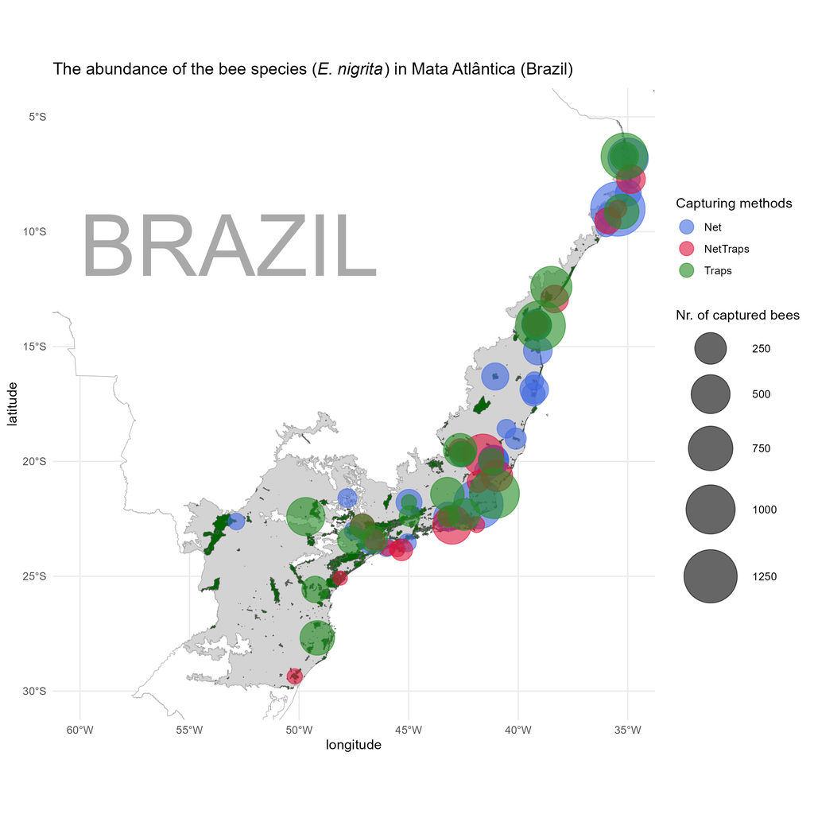

**Fig 1)** The source and number of collected bees. On the map of Brazil, the Atlantic forest biome is highlighted grey, with extra information about natural reserves (dark green), and sample sources are size-proportionatly plotted to their source of origin.

## Methods

### 1.) Data acquisition

The shape file for the country, Brazil, was downloaded using the [`geobr`](https://github.com/ipeaGIT/geobr) package (C.N. Goncalves et al.), while shape files for the region Mata Atlântica and conservation units were downloaded from the spatial data database, [TerraBrasilis](http://terrabrasilis.dpi.inpe.br/en/home-page/), curated by the Brazilian National Institute for Space Research (INPE) (L.F.F.G. Assis et al., 2019).

```r
brazil_map <- geobr::read_country()
region_map <- sf::st_read(paste(data_dir, 'biome_border.shp',sep = '/'))
units <- sf::st_read(paste(data_dir, 'conservation_units.shp',sep = '/'))
```

The raw data file containing the bee observations and other measurement data was acquired from the github repository directly.

| Eulaema_nigrita | SA | SU | method | effort | altitude | MAT | MAP | Tseason | Pseason | forest. | lu_het |
| --- | --- | --- | --- | --- | --- | --- | --- | --- | --- | --- | --- |
| 492 | Morro do Itaoca | 1-1 | NetTraps | 4.189655 | 6 | 235 | 1073 | 2036 | 53 | 0.0441640 | 1.0531299 |
| 372 | Estação Ecológica de Guaxindiba | 2-1 | Traps | 5.204007 | 17 | 230 | 987 | 1760 | 49 | 0.1821705 | 0.7571063 |
| 679 | Estação Ecológica de Guaxindiba | 2-2 | Traps | 5.204007 | 17 | 230 | 987 | 1760 | 49 | 0.1821705 | 0.7571063 |
| 600 | Mata do Funil | 2-3 | Traps | 5.204007 | 30 | 231 | 1030 | 1820 | 51 | 0.0157729 | 0.8277580 |
| 28 | Área de Proteção Ambiental da Barra do Rio Mamanguape | 6-1 | Net | 4.969813 | 0 | 259 | 1693 | 1074 | 62 | 0.0500000 | 0.9672604 |

There were several inconsistencies between the names used for the locations in the data file and used by the shape files, however the locations of the sample sources were still recognizable, hence the matching locations were selected based on a distance matrix built using longest common substring (lcs) distance. For this step the `stringdistmatrix()` function from the stringdist package was used. The type of the conservation unit (e.g natural park) was removed from the shape file names, to reduce misleading false positive hits in the matrix.

```r
# 1. pre-processing
unit_names <- units %>%
  # categoric values were substracted from the name of the units
  dplyr::mutate(name = stringr::str_remove(tolower(nome), tolower(categoria))) %>%
  # units were converted to a named character vector
  dplyr::pull(id, name = name)

# 2. creating the distance matrix
distance_matrix <- stringdistmatrix(a = unique(bee_file$SA), #data source
                                    b =  unique(names(unit_names)), #unit names
                                    useNames = T, # keep named vector
                                    method = 'lcs', # distance measure
                                    nthread = 4)

# 3.) extract the closest matching locations
get_min <- function(row){
  index <- which.min(row)
  return(names(row)[index]) # function to return the name of the closest match
}
matches <- apply(distance_matrix, 1, get_min)

# 4.  merging the bee data and location ids
matches <- data.frame(SA = names(matches),
                      name = matches,
                      id = unit_names[match(matches, names(unit_names))])
bee_data <- bee_data %>%
  merge(., matches, by = 'SA', all.x = T) %>%  #merge bee data with ids
  dplyr::left_join(., units, by = c('id' = 'id')) #join bee data a map data on ids
```

### 2.) Building a generalized liner model for predicting abundance

Generalized linear models (GLMs) add flexibility to the linear model by allowing deviations from the usual assumptions, extending linear regression to handle non-normal distributions and non-constant variance. In this case, when the response variable represents counts (number of captured bees), a negative binomial GLM was most suitable for modeling count data, accounting for the discrete and non-negative nature of count outcomes. In R, when fitting a negative binomial GLM using the `glm.nb()` function from the MASS package, the default link function, $g$ is the natural logarithm:

$$y = ln^{-1}(\eta)$$
As no correlation between the predictors was found, the final model was built, drawn from the results of a full model. The model used included a log hours of collection time, mean annual rainfall, and rainfall seasonality, temperature seasonality and forest coverage:

```r
glm.nb(Eulaema_nigrita ~ effort + MAP + Tseason + Pseason + forest.,
       data = bee_data)
```

```
##
## Call:  glm.nb(formula = Eulaema_nigrita ~ effort + MAP + Tseason + Pseason +
##     forest., data = bee_data, init.theta = 1.076928683, link = log)
##
## Coefficients:
## (Intercept)       effort          MAP      Tseason      Pseason      forest.
##   5.0379934    0.4048595   -0.0012492   -0.0007845    0.0156090   -0.9531966
##
## Degrees of Freedom: 177 Total (i.e. Null);  172 Residual
## Null Deviance:       378.1
## Residual Deviance: 205.3     AIC: 1776
```

## Results

### 1.) The most important predictor of bee abundance is the time spent collecting bees

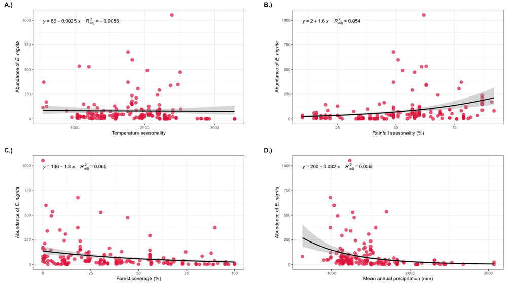

**Fig 2)** The Abundance of the be *E. nigrita* predicted to decrease with higher mean temperature variation over the months (A), increase with variation in rainfall (B), and decrease with higher forest coverage (C) and mean annual rainfall (D).

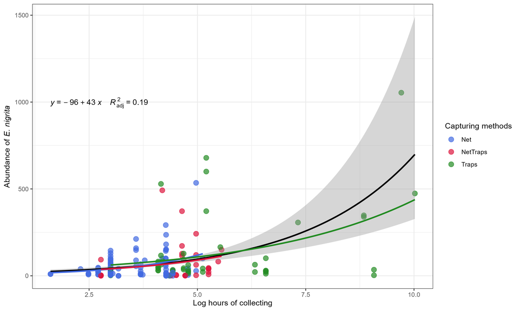

**Fig 3)** The Abundance of the be *E. nigrita* predicted to increase with time spent with capturing bees, which statement is true for all used capturing methods.

Table 1) Coefficients of the model `Eulaema_nigrita ~ effort + MAP + Tseason + Pseason + forest.`

|  | Estimate | Std. Error | z value | Pr(>\|z\|) |
| --- | --- | --- | --- | --- |
| (Intercept) | 5.0379934 | 0.4396539 | 11.458998 | 0.0000000 |
| effort | 0.4048595 | 0.0564200 | 7.175820 | 0.0000000 |
| MAP | -0.0012492 | 0.0001971 | -6.337994 | 0.0000000 |
| Tseason | -0.0007845 | 0.0001513 | -5.185384 | 0.0000002 |
| Pseason | 0.0156090 | 0.0037723 | 4.137785 | 0.0000351 |
| forest. | -0.9531966 | 0.2850451 | -3.344021 | 0.0008257 |